# FittingDistributions_Lecture_w6_2of2

## COMP 1814

### Week 6

#### Fitting Distributions (Lecture: Part 2/2)

*This week*

- Introduction
- Using fitdistrplus
  - Choosing which distribution to fit
  - fitting a distributions
  - Parameter estimates

```
Intro note: First of all team I hope you are all doing well. Following the larger concensus and not playing wrong we can all help minimise this at the earliest possible. Your families, will need the young ones to take lead in a number of things. So stay safe, make optimal decisions, and strengthen your character by following the general rules and not acting only by emotions. Containing from social gatherings etc will enable all of us to meet soon and assist all those heroes: Social Workers, Doctors, Supermarket staff, Drivers etc, all those who still keep the momemtum and allow to have the basics on our doorstep. You will always remember that without those no economy is moving. No economists, financial services person or anything exists without these people. These are the people who built and keep our homes going!
```

Two points before we start here: (i) I will setup a Monday evening call in Teams (will circulate meeting deals via email) so that we can go over anything you need (ii) You will need these notes for completing Q5 of the coursework - Fitting distributions. The data you will need are the ones on this page.

### Introduction

This far, most data we have worked with are normally distributed. But in most cases data, especially in certain disciplines, will not follow a normal distribution. In this lecture we wish to identify the tools that will allow us to identify a distribution that best describes the data we have at hand.

While we will not be able to perform t-tests as we know them if the data are not normally distributed (how to transform data will not be dealt here), identifying a distribution that best describes a dataset will allow us to simulate scenarios and create projections which we can use to support decision making.

For your **COURSEWORK** you will need to load the following data:

```
library(fitdistrplus)

data("groundbeef", package = "fitdistrplus")

my_data <- groundbeef$serving
```

Note: Next to each of my notes, I will give you a **CWK** so you know what you need to definitely use for the coursework.

Here I will create artificial data for the purpose of the examples we will be using:

- I will generate a sequence of 100000 numbers distributed following a Weibull distribution. Note: The Weibull distribution has more parameters than the normal distribution (mean and variance). Those are namely, (i) Location (you can think of this as the mean), (ii) scale (you may think of this as the variance), (iii) shape (with some caution you may think of this as the skewness)

  http://www.mathbitsnotebook.com/Algebra1/StatisticsData/STShapes.html

We will use the following parameters to create this distribution:  
c = location = 0 (shift from origin),  
b = scale = 2 and  
a = shape = 1

Some maths to have in mind:

The Weibull distribution with shape parameter a and scale parameter b has density given by

$f(x) = (a/b) (x/b)^(a-1) exp(- (x/b)^a) for x > 0$

The cumulative distribution function is (remember capital F for the cummulative distribution)

$F(x) = 1 - exp(- (x/b)^a) on x > 0$

Theoretical moments for Weibull distributions are:

\begin{eqnarray} Mean(X) &=& E(X) = c+b Γ(1 + 1/a)\\ Var(X) &=& b^2 * (Γ(1 + 2/a) - (Γ(1 + 1/a))^2) \end{eqnarray}

Let's do some work now in R

```r
# Let's create the (artificial) data
sample<- rweibull(100000, shape=1, scale = 2)
```

**CWK**  
Let's do some basic stats - just to revisit what we have done so far.  
Are the data normally distributed? We know they are not but lets double check this anyway - to confirm our previous methodology

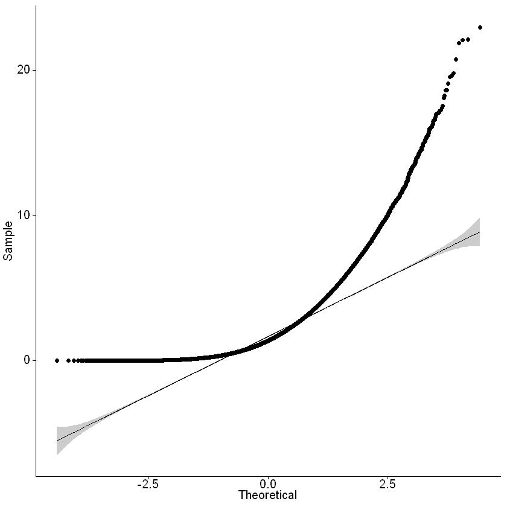

```r
## QQ plot
library(ggpubr)
ggqqplot(sample)
```

The data are clearly deviating from the normal distribution when plotting the quantiles against those of a normal  
**CWK**

```r
## Running a hypothesis test to support the visual
# note: sample size must be between 3 and 5000
# Jarque-Bera test is an alternative test
shapiro.test(sample[1:5000])
```

```
	Shapiro-Wilk normality test

data:  sample[1:5000]
W = 0.81924, p-value < 2.2e-16
```

We have strong evidence against the null hypothesis (Ho: Data are normal) since the p-value is significantly less than 5\%. So we accept that the data are not normally distributed (Ha: Data are not normal) with p<0.05

**CWK**  
Let's see how are data actually look like

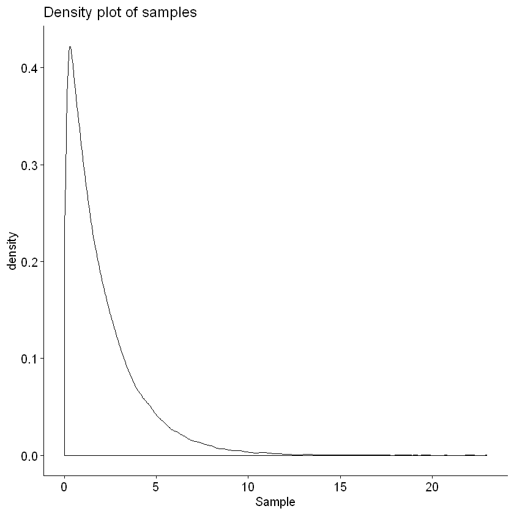

```r
# Plot the data histrogramm
ggdensity(sample,
          main = "Density plot of samples",
          xlab = "Sample")
```

[[**CWK**]]  
A few comments here:  
The distribution first of all has a support on the real line from [0,$\infty$] - This is actually a property of the Weibull distribution.

Observing things like this on the plot above will give an indication of what distribution may actually better fit the data. The normal distribution has support from [$-\infty$,$\infty$]

For info you can check more here: For your coursework we have provided you with the list of distributions you will need ot use. This is extra: https://en.wikipedia.org/wiki/List_of_probability_distributions

**CWK** (All cwk related)  
For the coursework we will be using a very handy package "fitdistrplus".

Let's install it, load it and do some plots and search for the best candidate distribution.

```r
# uncomment line below to install
#install.packages("fitdistrplus")
```

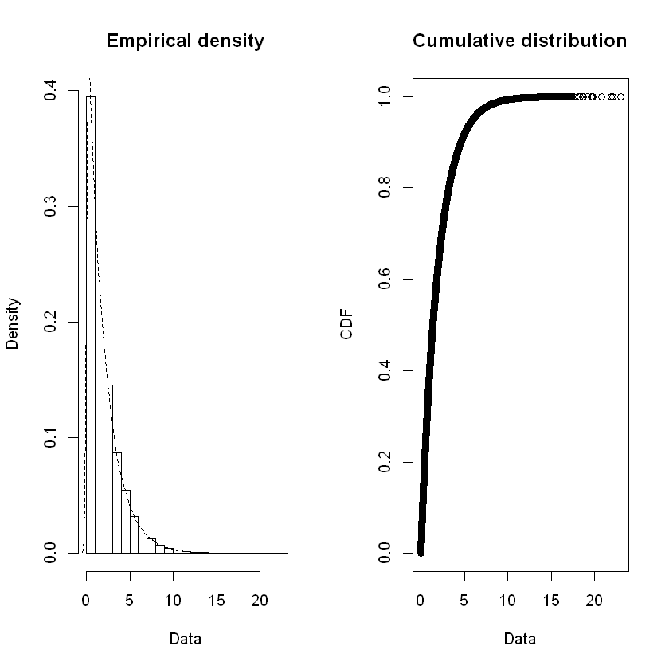

```r
library(fitdistrplus)
plotdist(sample, histo = TRUE, demp = TRUE)
```

This is how the distribution of our data look like. The dotted lines (on the left plot) are just a kernel or look at it as a line that best passess through the rectangles. Our aim in this exercise is to find a distribution that best matches this dotted line.

While you dont need this for your coursework it is good to know how to interpret this

```
summary statistics
------
min:  4.722327e-05   max:  22.97435
median:  1.383319
mean:  1.998763
estimated sd:  1.995775
estimated skewness:  1.987026
estimated kurtosis:  8.940845
```

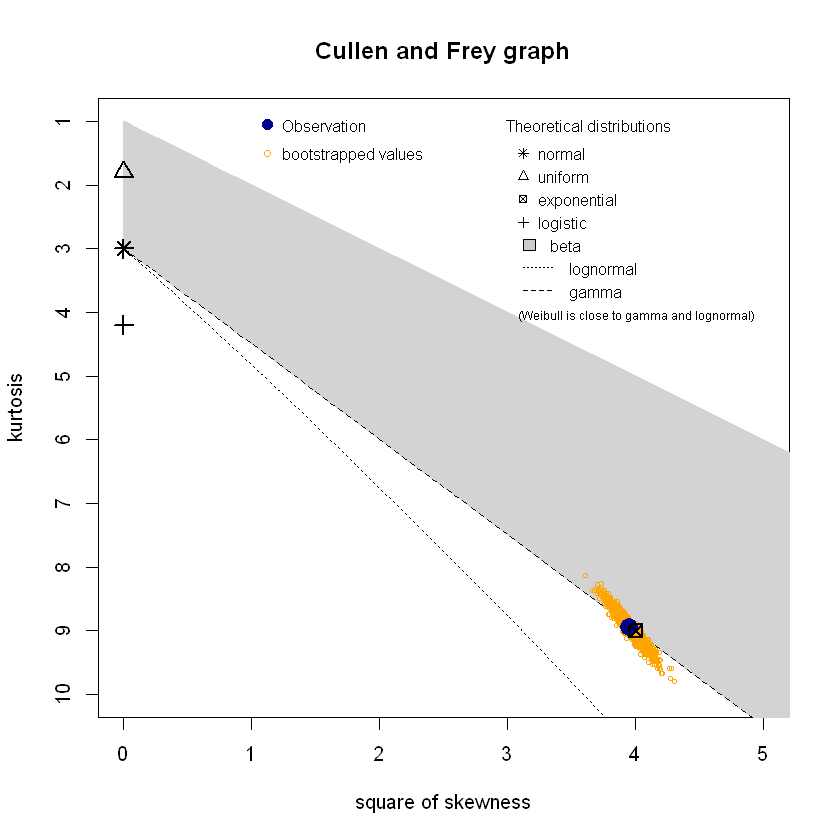

```r
descdist(sample, discrete=FALSE, boot=1000)
```

What we are trying to see from the plot above is which of the candidate distributions better capture the bootstrapped data points. To given you an example, the best fit is the distribution that the most yellow points fall on a line. Each distribution is a line (dashed or continuous or dotted). The beta distribution because each parameter is "dynamic" has a large shaded area (see link below)

From the plot above we can argus that the gamma/Weibull are the best candidates (ofcourse, in theory we dont know that the data here come from a Weibull distribution as we generated them - but with real data the true distribution is an unknown).

If you look at this link https://en.wikipedia.org/wiki/Beta_distribution and look at all the different shapes that the beta distribution can have you will understand why the large shaded ara. Nonetheless, most observations lie on the gamma distribution (which is a variant of the Weibull - for specific parameter).

### Fitting a distribution **CWK**

```r
# fit the 3 different distributions: Weibull, Gamma, LogNormal
fit_w  <- fitdist(sample, "weibull")
fit_g  <- fitdist(sample, "gamma")
fit_ln <- fitdist(sample, "lnorm")
```

```r
summary(fit_ln)
```

```
Fitting of the distribution ' lnorm ' by maximum likelihood
Parameters :
         estimate  Std. Error
meanlog 0.1153667 0.004056929
sdlog   1.2829136 0.002868674
Loglikelihood:  -178343.9   AIC:  356691.8   BIC:  356710.8
Correlation matrix:
        meanlog sdlog
meanlog       1     0
sdlog         0     1
```

```r
summary(fit_w)
```

```
Fitting of the distribution ' weibull ' by maximum likelihood
Parameters :
      estimate  Std. Error
shape 1.000251 0.002467222
scale 1.999140 0.006654936
Loglikelihood:  -169252.9   AIC:  338509.7   BIC:  338528.7
Correlation matrix:
          shape     scale
shape 1.0000000 0.3129009
scale 0.3129009 1.0000000
```

```r
summary(fit_g)
```

```
Fitting of the distribution ' gamma ' by maximum likelihood
Parameters :
       estimate  Std. Error
shape 0.9999524 0.003937470
rate  0.5002719 0.002526514
Loglikelihood:  -169252.9   AIC:  338509.7   BIC:  338528.8
Correlation matrix:
          shape      rate
shape 1.0000000 0.7796856
rate  0.7796856 1.0000000
```

The fitting criterion is always the LogLikelihood. The model with the highest LogLikelihood is the best fit model always. What we need to be cautious of nonetheless is the number of parameters used to estimate a model. If we use a model with many number of parameters it is likely that the model will have a better fit but it is also likely that we overfit. This means that the model may be good for explainign the history but not for explaining the out-of-sample data. To this end we need to consider the so called Akaike Information Criterion (AIC) and Bayesian Information Criterion (BIC). These penalise models based on the number of parameters (and the likelihood value). The model with the lowest is usually a better candidate.

So to summarise we need: (i) Higher Likelihood, and (ii) Lower BIC/AIC.

The highest liklihood and lower BIC/AIC here is the Weibull (almost identical to the gamma to be honest - this is because of the nature of the two distributions that are special cases of each other).

These information are enough for one to support the Weibull distribution as a good choise - when compared to these three. Let's prooce this visually too. Futher, progress in your studies you will see more criterion that can assist you in selecting a distribution fit.

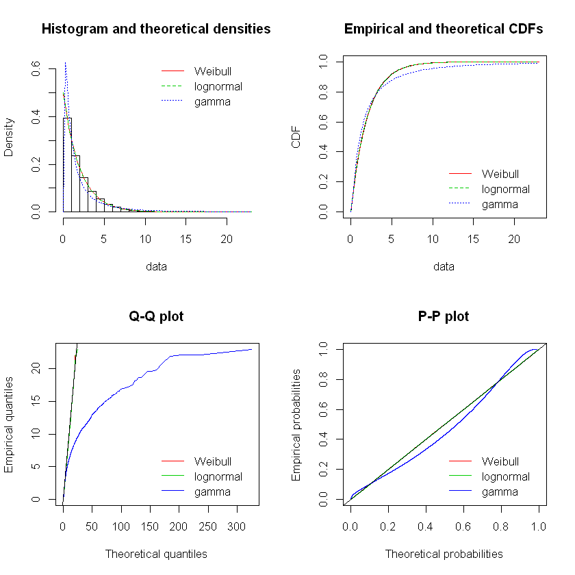

```r
par(mfrow=c(2,2))
plot.legend <- c("Weibull", "lognormal", "gamma")
denscomp(list(fit_w, fit_g, fit_ln), legendtext = plot.legend)
cdfcomp (list(fit_w, fit_g, fit_ln), legendtext = plot.legend)
qqcomp  (list(fit_w, fit_g, fit_ln), legendtext = plot.legend)
ppcomp  (list(fit_w, fit_g, fit_ln), legendtext = plot.legend)
```

Let's plot our candidate

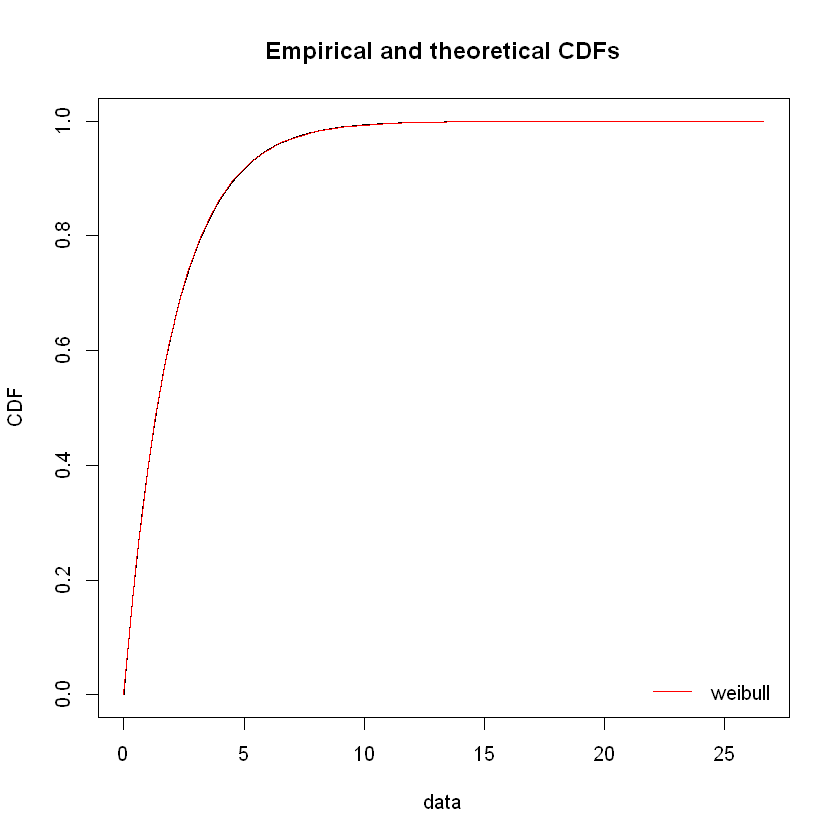

```r
cdfcomp(fit_w, xlogscale = FALSE, ylogscale = FALSE)
```

Here we can conlcude that we will go with the Weibul distribution as our best fit model.